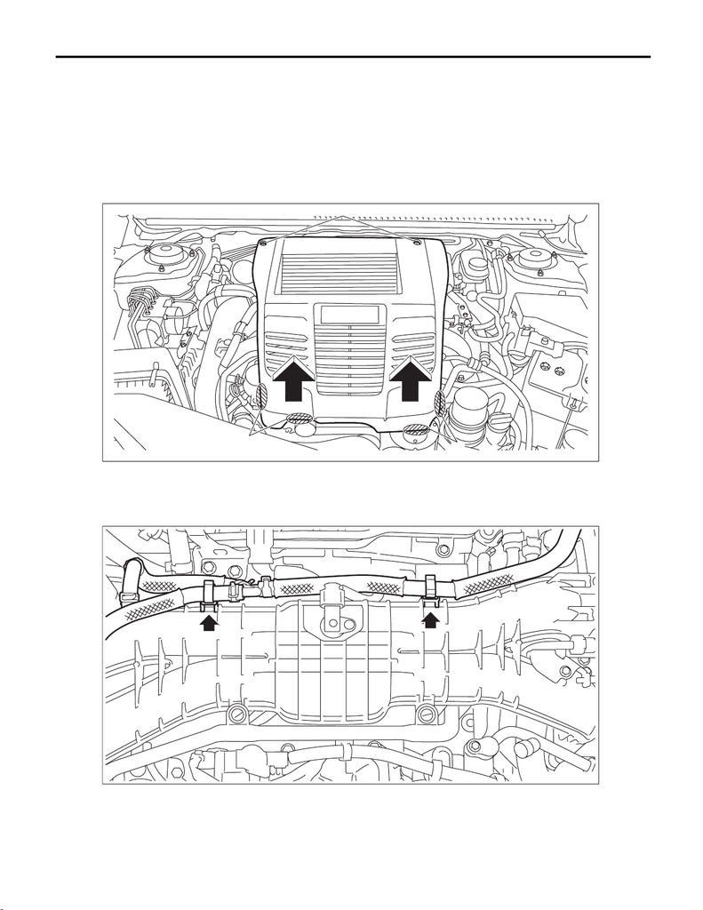

PCV Hose

EMISSION CONTROL (AUX. EMISSION CONTROL DEVICES)

15.PCV Hose

A: REMOVAL

CAUTION:

Do not remove except when the PCV hose is broken.

1) Remove the collector cover.

(1) Remove the clips (A).

(2) Hold the shaded area (B) by hand and carefully pull the RH side (C) upward.

(3) Hold the shaded area (D) by hand and carefully pull the LH side (E) upward.

2) Disconnect the ground terminal from battery sensor. <Ref. to NT-5, BATTERY, NOTE, Note.>

3) Remove the intercooler. <Ref. to IN(w/o STI)-38, REMOVAL, Intercooler.>

booster vacuum hose at the locations that do not interfere operation.

EX-03204

(A)

(B)

(C)

(E)

(D)

EC-03455

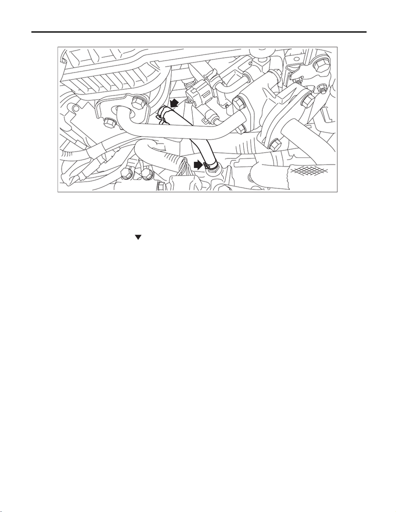

PCV Hose

EMISSION CONTROL (AUX. EMISSION CONTROL DEVICES)

5) Disconnect the PCV hose A from the intake manifold, and remove the PCV hose A from the PCV valve.

B: INSTALLATION

Install in the reverse order of removal.

NOTE:

to the position of alignment mark of intake manifold.

C: INSPECTION

Check that the PCV hose has no cracks, damage or loose part.

EC-03209